# Week 3 — Network Data & Spatial Data

## 7. Adjacency Matrix Representation

The third idiom from the lecture: instead of drawing nodes and links, we **derive a table** from the network — one row and one column per airport, where cell `(i, j)` is shaded if a route connects airport `i` to airport `j`.

```python
# Build the adjacency matrix directly from the graph — order matters for
# readability (the lecture's "Node order is crucial" slide), so we order
# airports by degree (most-connected first) rather than alphabetically,
# which visually groups the hub structure near the matrix's top-left corner.
node_order = layout_df.sort_values('degree', ascending=False)['iata'].tolist()
adj = nx.to_pandas_adjacency(G, nodelist=node_order)

fig_matrix = px.imshow(
    adj,
    color_continuous_scale=[[0, '#fcfcfb'], [1, '#2a78d6']],
    aspect='equal',
)
fig_matrix.update_layout(
    title="Ecuador's Domestic Flight Network — Adjacency Matrix<br>"
          "<sub>Ordered by degree (most-connected airports first) — same network as above</sub>",
    coloraxis_showscale=False,
    xaxis_title='', yaxis_title='',
    height=600, width=650,
)
fig_matrix.show()
```

[interactive chart not shown]

### Reading the matrix

Because we ordered airports by degree, the hub airports' rows/columns (**UIO**, **GYE**) show up as nearly-full rows and columns near the top-left — you can immediately see they connect to almost everything, without needing to trace a single line. Try finding **UIO's neighbors** in the matrix (scan its row) versus finding them in the node-link diagrams above — the matrix answers that question faster. Now try tracing a **two-hop path** from one low-degree airport to another that isn't a direct route — this is where the matrix becomes noticeably harder to use than the node-link diagram, exactly as the lecture predicts.

### Where the Matrix Actually Wins: A Denser Network

With only 14 airports, the node-link diagram was never really in trouble — both idioms stayed readable, so the comparison above couldn't show the matrix's real advantage. The lecture is specific about when that advantage kicks in: node-link diagrams work well for **small, sparse graphs**, but matrices become the better choice once a network gets **too dense to draw without becoming visual noise** (the lecture's empirical study cites node-link as best for small networks, matrix as best for large ones — provided the task doesn't require path-tracing).

To see that trade-off honestly, we scale up: instead of Ecuador alone, we build the domestic-and-regional flight network for **all of South America** — still the same `airports` / `routes` tables from Section 2, just without the `country == 'Ecuador'` filter from Section 3.

```python
# All South American airports (not just Ecuador), and all routes where BOTH
# endpoints are in South America — this reuses the exact same 'airports' and
# 'routes' tables loaded once in Section 2, just with a wider country filter.
south_america = [
    'Ecuador', 'Colombia', 'Peru', 'Venezuela', 'Brazil', 'Bolivia', 'Chile',
    'Argentina', 'Uruguay', 'Paraguay', 'Guyana', 'Suriname', 'French Guiana',
]
sa_airports = airports[airports['country'].isin(south_america)].copy()
sa_iata_codes = set(sa_airports['iata'].dropna())

sa_routes = routes[
    routes['src_iata'].isin(sa_iata_codes) & routes['dst_iata'].isin(sa_iata_codes)
].copy()
sa_edges = sa_routes[['src_iata', 'dst_iata']].drop_duplicates().reset_index(drop=True)

sa_nodes_in_use = set(sa_edges['src_iata']) | set(sa_edges['dst_iata'])
sa_nodes = sa_airports[sa_airports['iata'].isin(sa_nodes_in_use)].copy()

print(f"South American airports with connections: {len(sa_nodes)}")
print(f"South American unique routes: {len(sa_edges)}")
```

```
South American airports with connections: 303
South American unique routes: 1421
```

First, the node-link diagram — same geographic-layout approach as Section 4, just at 20x the scale.

```python
sa_coord = sa_nodes.set_index('iata')[['lat', 'lon']]

sa_edge_lat, sa_edge_lon = [], []
for _, row in sa_edges.iterrows():
    sa_edge_lat += [sa_coord.loc[row['src_iata'], 'lat'], sa_coord.loc[row['dst_iata'], 'lat'], None]
    sa_edge_lon += [sa_coord.loc[row['src_iata'], 'lon'], sa_coord.loc[row['dst_iata'], 'lon'], None]

fig_sa = go.Figure()
fig_sa.add_trace(go.Scattergeo(
    lat=sa_edge_lat, lon=sa_edge_lon, mode='lines',
    line=dict(width=0.4, color='#c3c2b7'), opacity=0.5,
    hoverinfo='none', showlegend=False,
))
fig_sa.add_trace(go.Scattergeo(
    lat=sa_nodes['lat'], lon=sa_nodes['lon'],
    mode='markers', marker=dict(size=3, color='#2a78d6'),
    hovertext=sa_nodes['name'] + ' (' + sa_nodes['city'] + ')',
    hoverinfo='text', showlegend=False,
))
fig_sa.update_geos(
    scope='south america',
    showcountries=True, countrycolor='#c3c2b7',
    showland=True, landcolor='#f9f9f7',
    showocean=True, oceancolor='#eaf2fb', coastlinecolor='#898781',
)
fig_sa.update_layout(
    title=f"South America's Flight Network — Node-Link Diagram<br>"
          f"<sub>{len(sa_nodes)} airports, {len(sa_edges)} routes — compare readability to the 14-node Ecuador map above</sub>",
    margin=dict(l=0, r=0, t=60, b=0), height=700,
)
fig_sa.show()
```

[interactive chart not shown]

At this density, the node-link diagram becomes exactly the "visual noise" the lecture warns about: hundreds of overlapping line segments make it essentially impossible to trace any individual airport's connections, and even the largest hubs are hard to distinguish from the general clutter. Zooming in would help locally, but there is no single static layout at this scale that stays readable everywhere at once.

Now the same network as an adjacency matrix.

```python
G_sa = nx.Graph()
G_sa.add_nodes_from(sa_nodes['iata'])
G_sa.add_edges_from(sa_edges[['src_iata', 'dst_iata']].values)

# Same degree-first ordering strategy as the Ecuador-only matrix — critical
# here, since with 300+ nodes an arbitrary (e.g. alphabetical) order would
# scatter the hub structure randomly across the matrix instead of grouping it.
sa_degree = dict(G_sa.degree())
sa_node_order = sorted(G_sa.nodes(), key=lambda n: -sa_degree[n])
adj_sa = nx.to_pandas_adjacency(G_sa, nodelist=sa_node_order)

fig_matrix_sa = px.imshow(
    adj_sa,
    color_continuous_scale=[[0, '#fcfcfb'], [1, '#2a78d6']],
    aspect='equal',
)
fig_matrix_sa.update_layout(
    title="South America's Flight Network — Adjacency Matrix<br>"
          "<sub>Ordered by degree (most-connected airports first) — same network as the map above</sub>",
    coloraxis_showscale=False,
    xaxis=dict(showticklabels=False, title=''),
    yaxis=dict(showticklabels=False, title=''),
    height=650, width=650,
)
fig_matrix_sa.show()
```

[interactive chart not shown]

### Reading the South America matrix

This is precisely the pattern the node-link diagram *couldn't* show cleanly at this scale — the matrix compresses hundreds of edges into a single glance-able image, at the cost of exactly the weakness the lecture predicts: you can no longer easily answer "how do I fly from a small Bolivian airstrip to a small Paraguayan one?" by tracing a path — that question needs the node-link diagram, or a routing algorithm, not the matrix. Neither idiom is strictly better; each earns its place for a different task, which is the lecture's core point about node-link vs. matrix representations.

### Coloring the Matrix by Community

Degree-ordering already revealed the hub structure, but it says nothing about **which airports cluster together** — two airports can both be high-degree without belonging to the same regional sub-network. Section 6 already showed how to detect that with Louvain community detection; the lecture's own "Node order is crucial: Reordering" slide (the *Les Misérables* example) makes the same point for matrices specifically: **reordering rows/columns by detected community**, instead of by degree, turns the block-diagonal structure into something you can literally see — each community becomes a solid square sitting on the diagonal.

```python
# Detect communities on the South America graph — same algorithm as Section 6,
# just applied to a much larger network.
sa_communities = louvain_communities(G_sa, seed=42)
sa_communities = sorted(sa_communities, key=len, reverse=True)  # largest first

print(f"Communities detected: {len(sa_communities)}")
for i, comm in enumerate(sa_communities):
    comm_countries = sa_nodes[sa_nodes['iata'].isin(comm)]['country'].value_counts()
    print(f"  Community {i} (size {len(comm)}): {dict(comm_countries)}")
```

```
Communities detected: 9
  Community 0 (size 74): {'Brazil': np.int64(74)}
  Community 1 (size 62): {'Colombia': np.int64(48), 'Ecuador': np.int64(14)}
  Community 2 (size 40): {'Argentina': np.int64(36), 'Paraguay': np.int64(2), 'Uruguay': np.int64(2)}
  Community 3 (size 36): {'Brazil': np.int64(33), 'Suriname': np.int64(1), 'French Guiana': np.int64(1), 'Guyana': np.int64(1)}
  Community 4 (size 35): {'Peru': np.int64(20), 'Bolivia': np.int64(15)}
  Community 5 (size 23): {'Venezuela': np.int64(23)}
  Community 6 (size 16): {'Chile': np.int64(16)}
  Community 7 (size 13): {'Brazil': np.int64(13)}
  Community 8 (size 4): {'Brazil': np.int64(4)}
```

```python
# Reorder the matrix by community FIRST, then by degree within each community —
# this groups every community into a contiguous, near-diagonal block, and
# orders each block internally so its own local hub still sits at the top-left.
community_of_sa = {node: i for i, comm in enumerate(sa_communities) for node in comm}
community_order = sorted(
    G_sa.nodes(),
    key=lambda n: (community_of_sa[n], -sa_degree[n])
)
adj_sa_comm = nx.to_pandas_adjacency(G_sa, nodelist=community_order)

# A qualitative palette with enough distinct hues for 9 communities — at this
# node count the color's job is to make block boundaries visible, not to pass
# a strict CVD-pairwise check the way a 3-4 category chart would.
community_palette = px.colors.qualitative.Set1 + px.colors.qualitative.Set3
community_ids = [community_of_sa[n] for n in community_order]

# Recolor each cell: 0 stays "no connection" (background), 1 becomes the
# ROW airport's community index + 1 — so filled cells inherit their row's
# community color instead of a single flat blue.
adj_colored = adj_sa_comm.copy()
for i, node in enumerate(community_order):
    adj_colored.iloc[i] = adj_colored.iloc[i] * (community_of_sa[node] + 1)

fig_matrix_comm = px.imshow(
    adj_colored,
    color_continuous_scale=[[0, '#fcfcfb']] + [
        [(_i + 1) / len(sa_communities), community_palette[_i]]
        for _i in range(len(sa_communities))
    ],
    aspect='equal',
)
fig_matrix_comm.update_layout(
    title="South America's Flight Network — Adjacency Matrix Colored by Community<br>"
          "<sub>Rows/columns grouped by Louvain community, then by degree within each — "
          "compare block boundaries to the country breakdown above</sub>",
    coloraxis_showscale=False,
    xaxis=dict(showticklabels=False, title=''),
    yaxis=dict(showticklabels=False, title=''),
    height=650, width=650,
)
fig_matrix_comm.show()
```

[interactive chart not shown]

### Reading the community-colored matrix

Reordering by community turns the diffuse pattern from the degree-only matrix into **visible blocks along the diagonal** — each solid-colored square is one detected community, and because most of a community's connections stay *within* the community, the vast majority of colored cells cluster inside these blocks rather than scattering across the whole matrix. The faint marks *outside* the diagonal blocks are the cross-community routes — the direct flights that cross a "national" boundary in the network's structure, like a Bogotá–Lima or Buenos Aires–São Paulo connection. Those off-diagonal marks are comparatively rare, which is exactly what "community" means in graph terms: dense connections inside the group, sparse connections crossing between groups.

# Part 2 — Spatial Data

## 8. Loading Canton Boundaries

Both spatial datasets in this part are joined against the same official **canton-level GeoJSON** (downloaded from the course dataset repository, same as every other dataset in this notebook) — 224 polygons, one per Ecuadorian canton, each carrying a `DPA_CANTON` code (e.g. `"0101"`) that we will use as the join key. Loading it once here keeps Section 9 (choropleth) and Section 10 (symbol map / dot density) from duplicating this step.

```python
CANTONES_GEOJSON_URL = ('https://raw.githubusercontent.com/CarlaGeovanna/'
                         'datasets_public/refs/heads/main/cantones-ecuador.geojson')

with urllib.request.urlopen(CANTONES_GEOJSON_URL) as response:
    cantones_geojson = json.load(response)

print(f"Canton polygons loaded: {len(cantones_geojson['features'])}")
print("Sample properties:", cantones_geojson['features'][0]['properties'])
```

```
Canton polygons loaded: 224
Sample properties: {'DPA_VALOR': 0, 'DPA_ANIO': '2011', 'DPA_CANTON': '0101', 'DPA_DESCAN': 'CUENCA', 'DPA_PROVIN': '01', 'DPA_DESPRO': 'AZUAY', 'PCODE2': 'EC0101'}
```

## 9. Choropleth Map: Conservation Area by Canton (MAATE)

Our first spatial dataset comes from Ecuador's **Ministry of Environment, Water and Ecological Transition (MAATE)**: the surface area (in hectares) under some form of conservation status, recorded per canton/parish as of December 2022. Conservation categories include `SNAP` (National System of Protected Areas), `PSB` (Socio Bosque forest-conservation program), `MANGLAR` (mangrove), and `BVP` (Protective Forest and Vegetation).

This is a natural fit for a **choropleth map** — per the lecture, choropleths work best when the central task is understanding *spatial relationships* in a single quantitative variable per region, and conservation area (a genuine per-region total, not a population-driven count) is exactly that kind of variable.

```python
MAATE_URL = ('https://raw.githubusercontent.com/CarlaGeovanna/'
             'datasets_public/main/maate_superficiebajoconservacion_2022diciembre.csv')

maate = pd.read_csv(MAATE_URL, sep=';', encoding='latin-1')

# AREA_HA is stored with a comma as the decimal separator (a common convention
# in Spanish-language government exports) — pandas would otherwise read this
# column as text instead of a number.
maate['AREA_HA'] = maate['AREA_HA'].str.replace(',', '.').astype(float)

print(f"Rows: {len(maate):,}")
maate.head()
```

```
Rows: 5,162
```

|  | ANIO_REPORT | DPA_PROVIN | DPA_DESPRO | DPA_CANTON | DPA_DESCAN | DPA_PARROQ | DPA_DESPAR | TXT | TXT_1 | NAM | CAT_GESTION | AREA_HA |
| --- | --- | --- | --- | --- | --- | --- | --- | --- | --- | --- | --- | --- |
| 0 | 2022 | 15 | NAPO | 1507 | QUIJOS | 150750 | BAEZA | CABECERA CANTONAL | Terrestre | ANTISANA | SNAP | 8550.58 |
| 1 | 2022 | 17 | PICHINCHA | 1701 | DISTRITO METROPOLITANO DE QUITO | 170175 | PIFO | PARROQUIA RURAL | Terrestre | ANTISANA | SNAP | 17.99 |
| 2 | 2022 | 15 | NAPO | 1507 | QUIJOS | 150752 | CUYUJA | PARROQUIA RURAL | Terrestre | ANTISANA | SNAP | 9415.45 |
| 3 | 2022 | 15 | NAPO | 1507 | QUIJOS | 150751 | COSANGA | PARROQUIA RURAL | Terrestre | ANTISANA | SNAP | 31670.92 |
| 4 | 2022 | 15 | NAPO | 1503 | ARCHIDONA | 150350 | ARCHIDONA | CABECERA CANTONAL | Terrestre | ANTISANA | SNAP | 400.86 |

### Cleaning: two non-canton codes

Two `DPA_CANTON` codes in this dataset are **not real cantons** and would distort the map if left in:

- **`9999` ("MARINA")** — a placeholder for marine protected areas that don't belong to any single canton's land territory. At ~20.9 million hectares (dwarfing every actual canton's area), including it would make every real canton's conservation area look negligible by comparison on the color scale.
- **`8888` ("ISLA")** — a generic placeholder code, not a real canton.

We also fix one canton-boundary mismatch: code **`2302`** ("La Concordia", recorded under Santo Domingo de los Tsáchilas province) doesn't exist in our 2011-vintage GeoJSON, because La Concordia was administratively transferred from Esmeraldas to Santo Domingo province in **2013** — after the boundary file was published. Its territory in the GeoJSON is still filed under its pre-2013 code, **`0808`** (also named "La Concordia", under Esmeraldas). We remap it rather than drop it, so the canton's conservation area isn't silently lost from the map.

```python
# Drop the two non-canton placeholder codes
maate_clean = maate[~maate['DPA_CANTON'].isin([9999, 8888])].copy()

# Zero-pad to match the GeoJSON's 4-character string codes (e.g. 101 -> '0101')
maate_clean['DPA_CANTON'] = maate_clean['DPA_CANTON'].astype(str).str.zfill(4)

# Remap La Concordia's post-2013 code to its pre-2013 code, which is what the
# 2011-vintage boundary file actually contains.
maate_clean['DPA_CANTON'] = maate_clean['DPA_CANTON'].replace({'2302': '0808'})

# Verify every remaining canton code exists in the GeoJSON boundaries —
# an unmatched code would silently disappear from the choropleth.
geo_canton_codes = {f['properties']['DPA_CANTON'] for f in cantones_geojson['features']}
unmatched = set(maate_clean['DPA_CANTON']) - geo_canton_codes
assert not unmatched, f"Unmatched canton codes: {unmatched}"
print(f"All {maate_clean['DPA_CANTON'].nunique()} canton codes matched to GeoJSON boundaries.")
```

```
All 188 canton codes matched to GeoJSON boundaries.
```

```python
# Aggregate to one total hectares figure per canton (a canton can have
# multiple rows: one per parish, and/or one per conservation category).
conservation_by_canton = (
    maate_clean.groupby(['DPA_CANTON', 'DPA_DESCAN'])['AREA_HA']
    .sum()
    .reset_index()
)

print(f"Cantons with conservation area on record: {len(conservation_by_canton)}")
conservation_by_canton.sort_values('AREA_HA', ascending=False).head(10)
```

```
Cantons with conservation area on record: 188
```

|  | DPA_CANTON | DPA_DESCAN | AREA_HA |
| --- | --- | --- | --- |
| 142 | 1601 | PASTAZA | 788678.15 |
| 182 | 2202 | AGUARICO | 668175.18 |
| 172 | 2002 | ISABELA | 547274.38 |
| 145 | 1604 | ARAJUNO | 450289.95 |
| 180 | 2107 | CUYABENO | 335097.38 |
| 139 | 1504 | EL CHACO | 306047.24 |
| 125 | 1401 | MORONA | 254815.77 |
| 138 | 1503 | ARCHIDONA | 250855.46 |
| 65 | 0802 | ELOY ALFARO | 191379.06 |
| 0 | 0101 | CUENCA | 185841.37 |

```python
fig_choro = px.choropleth(
    conservation_by_canton,
    geojson=cantones_geojson,
    locations='DPA_CANTON',
    featureidkey='properties.DPA_CANTON',
    color='AREA_HA',
    color_continuous_scale='Greens',   # sequential: one hue, more-is-darker
    hover_name='DPA_DESCAN',
    labels={'AREA_HA': 'Conservation area (ha)'},
)
fig_choro.update_geos(fitbounds='locations', visible=False)
fig_choro.update_layout(
    title='Surface Area Under Conservation by Canton — Ecuador, December 2022<br>'
          '<sub>Sequential color scale: darker green = more hectares under conservation</sub>',
    margin=dict(l=0, r=0, t=60, b=0), height=650,
)
fig_choro.show()
```

[interactive chart not shown]

### Reading the choropleth

The darkest cantons cluster in the **Amazon region** (Napo, Pastaza, Sucumbíos, Orellana, Morona Santiago) — vast, sparsely populated cantons that contain large stretches of protected rainforest, national parks, and Socio Bosque conservation agreements. Coastal and highland cantons, which tend to be smaller and more densely populated with land under agriculture or urban use, show far less conservation area in absolute hectares.

Per the lecture's choropleth recommendations, this map is honest **because the variable itself — total hectares under conservation — genuinely is a per-region quantity**, not something that scales with each canton's population or land area in a way that would need normalizing. (Contrast this with Part 2's next dataset, where normalizing by population turns out to matter a great deal.)

## 10. Proportional Symbol Map & Dot Density: Detentions/Apprehensions (MDI)

Our second spatial dataset comes from Ecuador's **Ministry of the Interior**: individual-level records of detentions and apprehensions nationwide, January through June 2026. Unlike the MAATE data, this file gives us something rarer — **exact latitude/longitude for every single incident**, not just a canton code. That lets us build two different idioms from the *same* underlying data: a proportional symbol map (aggregated by canton) and a genuine dot density map (one dot per real incident location, not simulated).

As with MAATE's `AREA_HA` column, `latitud` and `longitud` are stored as text with a **comma decimal separator** (`'-2,293860393'`) — the same Spanish-locale export convention, so we convert both columns to numbers explicitly right after loading.

```python
MDI_URL = ('https://raw.githubusercontent.com/CarlaGeovanna/'
           'datasets_public/main/mdi_detenidosaprehendidos_pm_2026_enero_junio.xlsx')

# Excel files can't be streamed row-by-row like a CSV url, so we download the
# raw bytes first and read the workbook from memory.
import io

with urllib.request.urlopen(MDI_URL) as response:
    mdi_bytes = response.read()

mdi = pd.read_excel(io.BytesIO(mdi_bytes), sheet_name='1. Detenidos y Aprehendidos')

# latitud/longitud are stored as TEXT with a comma decimal separator
# (e.g. '-2,293860393'), the same Spanish-locale export convention we saw in
# the MAATE file's AREA_HA column — pandas reads them as strings until we
# convert them explicitly.
mdi['latitud'] = mdi['latitud'].astype(str).str.replace(',', '.').astype(float)
mdi['longitud'] = mdi['longitud'].astype(str).str.replace(',', '.').astype(float)

print(f"Rows: {len(mdi):,}")
mdi[['tipo', 'edad', 'sexo', 'codigo_provincia', 'nombre_provincia',
     'codigo_canton', 'nombre_canton', 'presunta_infraccion',
     'latitud', 'longitud']].head()
```

```
Rows: 37,876
```

|  | tipo | edad | sexo | codigo_provincia | nombre_provincia | codigo_canton | nombre_canton | presunta_infraccion | latitud | longitud |
| --- | --- | --- | --- | --- | --- | --- | --- | --- | --- | --- |
| 0 | DETENIDO | 66 | HOMBRE | 14 | MORONA SANTIAGO | 1401 | MORONA | BOLETAS | -2.293860 | -78.098405 |
| 1 | APREHENDIDO | SIN_DATO | MUJER | 9 | GUAYAS | 920 | SAN JACINTO DE YAGUACHI | DELITOS POR LA PRODUCCIÓN O TRÁFICO ILÍCITO DE... | -2.248278 | -79.655842 |
| 2 | APREHENDIDO | 30 | HOMBRE | 17 | PICHINCHA | 1701 | QUITO | DELITOS CONTRA EL DERECHO A LA PROPIEDAD | -0.096702 | -78.425187 |
| 3 | APREHENDIDO | 27 | HOMBRE | 19 | ZAMORA CHINCHIPE | 1902 | CHINCHIPE | DELITOS DE VIOLENCIA CONTRA LA MUJER O MIEMBRO... | -4.865445 | -79.134021 |
| 4 | APREHENDIDO | 14 | HOMBRE | 19 | ZAMORA CHINCHIPE | 1901 | ZAMORA | DELITOS POR LA PRODUCCIÓN O TRÁFICO ILÍCITO DE... | -4.066888 | -78.951242 |

### Cleaning: the same canton-code issues, plus one new one

`codigo_canton` needs the same two fixes as the MAATE data above (the La Concordia boundary remap), plus one MDI-specific case: code **`0`** ("MAR TERRITORIAL") marks incidents that happened in **territorial waters**, outside any canton's land boundary — real, valid incidents with real coordinates, just not attributable to a specific canton. We keep these for the dot density map (which only needs lat/lon) but exclude them from the canton-aggregated symbol map (which needs a valid canton to attach to).

```python
# codigo_canton is numeric in the source file; zero-pad to match GeoJSON codes.
mdi['codigo_canton'] = mdi['codigo_canton'].astype(str).str.zfill(4)

# Same 2013 boundary remap as the MAATE dataset (La Concordia).
mdi['codigo_canton'] = mdi['codigo_canton'].replace({'2302': '0808'})

# Territorial-water incidents (code '0000') have no canton — valid for the
# dot density map (has real coordinates) but excluded from canton aggregation.
mdi_land = mdi[mdi['codigo_canton'] != '0000'].copy()

unmatched = set(mdi_land['codigo_canton']) - geo_canton_codes
assert not unmatched, f"Unmatched canton codes: {unmatched}"
print(f"Land-based incidents: {len(mdi_land):,} / {len(mdi):,} total")
print(f"Territorial-water incidents (kept for dot map, excluded from canton totals): "
      f"{(mdi['codigo_canton'] == '0000').sum()}")
```

```
Land-based incidents: 37,828 / 37,876 total
Territorial-water incidents (kept for dot map, excluded from canton totals): 48
```

### Choosing the color channel

`presunta_infraccion` (alleged offense category) has 46 distinct values — far too many for direct color encoding (recall the course's color methodology: a scatter/bubble map's all-pairs colorblind-safety check caps out at **4** categorical slots). We group the offense categories into the three largest plus an "Otro" bucket, exactly as we did with accident types in the traffic fatality symbol map earlier this course.

```python
print(mdi_land['presunta_infraccion'].value_counts().head(6))
```

```
presunta_infraccion
DELITOS CONTRA EL DERECHO A LA PROPIEDAD                                                         6033
DELITOS POR LA PRODUCCIÓN O TRÁFICO ILÍCITO DE SUSTANCIAS CATALOGADAS SUJETAS A FISCALIZACIÓN    5878
BOLETAS                                                                                          4787
DELITOS CONTRA LA EFICIENCIA DE LA ADMINISTRACIÓN PÚBLICA                                        3975
CONTRAVENCIONES DE TRÁNSITO                                                                      3869
DELITOS CONTRA LA SEGURIDAD PÚBLICA                                                              2843
Name: count, dtype: int64
```

```python
top_infractions = [
    'DELITOS CONTRA EL DERECHO A LA PROPIEDAD',
    'DELITOS POR LA PRODUCCIÓN O TRÁFICO ILÍCITO DE SUSTANCIAS CATALOGADAS SUJETAS A FISCALIZACIÓN',
    'BOLETAS',
]
mdi_land['infraccion_agrupada'] = mdi_land['presunta_infraccion'].where(
    mdi_land['presunta_infraccion'].isin(top_infractions), 'Otro'
)

infraccion_colors = {
    top_infractions[0]: '#2a78d6',  # blue
    top_infractions[1]: '#008300',  # green
    top_infractions[2]: '#e87ba4',  # magenta
    'Otro':              '#eda100', # yellow
}
infraccion_order = top_infractions + ['Otro']
infraccion_labels = {
    top_infractions[0]: 'Contra la propiedad',
    top_infractions[1]: 'Tráfico de sustancias',
    top_infractions[2]: 'Boletas (orden de captura)',
    'Otro': 'Otro',
}
mdi_land['infraccion_label'] = mdi_land['infraccion_agrupada'].map(infraccion_labels)
```

```python
# Aggregate to one row per (canton, offense group) — one circle per row.
agg_mdi = (
    mdi_land.groupby(['codigo_canton', 'nombre_canton', 'infraccion_label'])
    .size()
    .reset_index(name='Casos')
)

# Attach each canton's centroid for plotting. Ecuador's cantons don't ship
# with pre-computed centroids in this GeoJSON, so we approximate each
# canton's anchor point as the mean lat/lon of its incidents — good enough
# for a symbol map (unlike Section 9's choropleth, which uses the true
# polygon boundaries directly and needs no point approximation at all).
canton_centroid = (
    mdi_land.groupby('codigo_canton')[['latitud', 'longitud']]
    .mean()
    .rename(columns={'latitud': 'lat', 'longitud': 'lon'})
)
agg_mdi = agg_mdi.merge(canton_centroid, on='codigo_canton', how='left')

print(f"Circles on the symbol map: {len(agg_mdi)}")
agg_mdi.sort_values('Casos', ascending=False).head(8)
```

```
Circles on the symbol map: 758
```

|  | codigo_canton | nombre_canton | infraccion_label | Casos | lat | lon |
| --- | --- | --- | --- | --- | --- | --- |
| 607 | 1701 | QUITO | Otro | 2658 | -0.192806 | -78.487556 |
| 239 | 0901 | GUAYAQUIL | Otro | 2200 | -2.178784 | -79.928195 |
| 240 | 0901 | GUAYAQUIL | Tráfico de sustancias | 1489 | -2.178784 | -79.928195 |
| 238 | 0901 | GUAYAQUIL | Contra la propiedad | 1314 | -2.178784 | -79.928195 |
| 605 | 1701 | QUITO | Boletas (orden de captura) | 1058 | -0.192806 | -78.487556 |
| 608 | 1701 | QUITO | Tráfico de sustancias | 1030 | -0.192806 | -78.487556 |
| 606 | 1701 | QUITO | Contra la propiedad | 977 | -0.192806 | -78.487556 |
| 338 | 1001 | IBARRA | Otro | 560 | 0.374756 | -78.127181 |

```python
fig_symbol = px.scatter_geo(
    agg_mdi,
    lat='lat', lon='lon',
    size='Casos',
    color='infraccion_label',
    category_orders={'infraccion_label': list(infraccion_labels.values())},
    color_discrete_map={v: infraccion_colors[k] for k, v in infraccion_labels.items()},
    hover_name='nombre_canton',
    hover_data={'infraccion_label': True, 'Casos': True, 'lat': False, 'lon': False},
    size_max=40, opacity=0.7,
    scope='south america',
)
fig_symbol.update_geos(
    lataxis_range=[-6, 2], lonaxis_range=[-92, -74],
    showcountries=True, countrycolor='#c3c2b7',
    showland=True, landcolor='#f9f9f7',
    showocean=True, oceancolor='#eaf2fb', coastlinecolor='#898781',
)
fig_symbol.update_traces(marker=dict(line=dict(width=0.4, color='white')))
fig_symbol.update_layout(
    title='Detentions/Apprehensions by Canton — Jan–Jun 2026<br>'
          '<sub>Circle size = total cases · Circle color = offense category</sub>',
    legend_title_text='Offense category',
    margin=dict(l=0, r=0, t=70, b=0), height=650,
)
fig_symbol.show()
```

[interactive chart not shown]

## 11. Dot Density Map: Individual Incident Locations

Because this dataset has real per-incident coordinates, we can build the idiom the lecture describes as visualizing "distribution of a phenomenon by placing dots" — but with a twist. The lecture's own example map (a population-density map of the US) has a legend reading "1 Dot = 50,000 Population": each dot there stands in for a **fixed count of people**, not a single real observation, because census data is normally only available pre-aggregated by region, not as one row per person. That 50,000 figure is just what that particular map's data required — a dot density map's scale is always chosen per-dataset, not a fixed convention. Here we can do better than even that: our MDI data is already at the individual-incident level, so **each dot is one real incident** at its true recorded location — no aggregation, no per-dot scale to choose, no simulation needed.

```python
fig_dot = px.scatter_geo(
    mdi,  # full dataset, including the 48 territorial-water incidents
    lat='latitud', lon='longitud',
    scope='south america',
    opacity=0.35,
)
fig_dot.update_traces(marker=dict(size=3, color='#2a78d6'))
fig_dot.update_geos(
    lataxis_range=[-6, 2], lonaxis_range=[-92, -74],
    showcountries=True, countrycolor='#c3c2b7',
    showland=True, landcolor='#f9f9f7',
    showocean=True, oceancolor='#eaf2fb', coastlinecolor='#898781',
)
fig_dot.update_layout(
    title='Dot Density Map — Every Detention/Apprehension, Jan–Jun 2026<br>'
          '<sub>One dot = one real incident (exact recorded coordinates)</sub>',
    margin=dict(l=0, r=0, t=60, b=0), height=650,
)
fig_dot.show()
```

[interactive chart not shown]

### Reading the dot density map

The densest clusters sit directly on **Quito** and **Guayaquil** — which, per the lecture's "Beware: population maps trickiness" warning, is exactly what you'd expect from *any* map of a phenomenon that scales with population density, regardless of what the phenomenon actually is. A dense cluster over a city center does not, by itself, tell us whether that city has a disproportionately *high rate* of incidents — it may simply have more people. This is precisely the trap the next section addresses directly.

### Finding Clusters Automatically — By Incident Profile, Not Location

The previous map already answered *where* incidents concentrate. Now we ask a genuinely different question: does the **same kind** of incident — the same mix of offense, place type, mobilization, and timing — show up as a repeatable pattern in many different parts of the country, or is every region's mix of incidents unique to that region? Answering that requires clustering on **incident profile**, not on location — so this time we run DBSCAN on a feature set that deliberately excludes every column that names or encodes a place.

**Final feature set:**

- `infraccion_agrupada` — the four-bucket offense grouping we already built in Section 10 (reused as-is, not rebuilt)
- `tipo_lugar` — category of place
- `movilizacion` — how the person was moving (on foot, by car, by motorcycle, ...)
- `tipo_arma` — weapon category present, if any
- `hour_of_day` — derived from `hora_detencion_aprehension`; a behavioral signal (time of day), not a spatial one
- `day_of_week` — derived from `fecha_detencion_aprehension`; same reasoning

```python
# ColumnTransformer/OneHotEncoder/StandardScaler are all from sklearn, so one
# defensive try/except covers everything this cell needs (same pattern as
# the DBSCAN import above).
try:
    from sklearn.cluster import DBSCAN
    from sklearn.compose import ColumnTransformer
    from sklearn.preprocessing import OneHotEncoder, StandardScaler
except ImportError:
    !pip install scikit-learn
    from sklearn.cluster import DBSCAN
    from sklearn.compose import ColumnTransformer
    from sklearn.preprocessing import OneHotEncoder, StandardScaler

import numpy as np

# Two behavioral time features, derived from the timestamp columns —
# when an incident happened, not where.
mdi_land['hour_of_day'] = pd.to_datetime(
    mdi_land['hora_detencion_aprehension'].astype(str), format='%H:%M:%S'
).dt.hour
mdi_land['day_of_week'] = mdi_land['fecha_detencion_aprehension'].dt.dayofweek

categorical_features = ['infraccion_agrupada', 'tipo_lugar', 'movilizacion', 'tipo_arma']
numeric_features = ['hour_of_day', 'day_of_week']

# One-hot encode the categoricals, standard-scale the numerics, and
# concatenate the result into a single numeric matrix DBSCAN can use.
encoder = ColumnTransformer([
    ('cat', OneHotEncoder(handle_unknown='ignore'), categorical_features),
    ('num', StandardScaler(), numeric_features),
])
X_profile = encoder.fit_transform(mdi_land[categorical_features + numeric_features])
print(f"Encoded feature matrix shape: {X_profile.shape}")

EPS_PROFILE = 0.7        # Euclidean distance in standardized/one-hot space —
                          # no physical unit; chosen empirically
MIN_SAMPLES_PROFILE = 30  # an incident profile needs at least 30 similar
                           # neighbors to count as a recurring pattern

db_profile = DBSCAN(eps=EPS_PROFILE, min_samples=MIN_SAMPLES_PROFILE, metric='euclidean')
mdi_land['cluster'] = db_profile.fit_predict(X_profile)

n_clusters = mdi_land['cluster'].nunique() - (1 if -1 in mdi_land['cluster'].values else 0)
n_noise = (mdi_land['cluster'] == -1).sum()
print(f"Profile clusters found: {n_clusters}")
print(f"Incidents with no similar-profile neighbors (noise): "
      f"{n_noise:,} ({100 * n_noise / len(mdi_land):.1f}% of all incidents)")

# Evidence for the claim in the next markdown cell: are these profile
# clusters confined to one place, or do they recur nationally? For each of
# the five largest clusters, count how many of Ecuador's 24 provinces its
# points touch.
top5 = mdi_land['cluster'].value_counts().drop(-1, errors='ignore').head(5)
dispersion = pd.DataFrame({
    'cluster': top5.index,
    'incidents': top5.values,
    'provinces_touched': [
        mdi_land.loc[mdi_land['cluster'] == cid, 'nombre_provincia'].nunique()
        for cid in top5.index
    ],
})
print("\nTop 5 clusters by size — how many of Ecuador's 24 provinces each touches:")
dispersion
```

```
Encoded feature matrix shape: (37828, 40)
Profile clusters found: 61
Incidents with no similar-profile neighbors (noise): 5,483 (14.5% of all incidents)

Top 5 clusters by size — how many of Ecuador's 24 provinces each touches:
```

|  | cluster | incidents | provinces_touched |
| --- | --- | --- | --- |
| 0 | 4 | 4424 | 24 |
| 1 | 9 | 2977 | 24 |
| 2 | 6 | 2415 | 24 |
| 3 | 0 | 2293 | 24 |
| 4 | 3 | 2139 | 24 |

### Labeling Each Point with Its Canton (Hover Context Only)

The clustering never used geographic data — it grouped points purely by incident profile. Once mapped, we simply attach each point's canton name for hover context, using the same point-in-polygon join as before (via Shapely's STRtree) — purely descriptive, since it plays no role in defining the clusters themselves.

```python
from shapely.geometry import shape
from shapely import points as shapely_points
from shapely.strtree import STRtree

canton_polygons = [shape(f['geometry']) for f in cantones_geojson['features']]
canton_names_list = [f['properties']['DPA_DESCAN'] for f in cantones_geojson['features']]
canton_tree = STRtree(canton_polygons)

# Vectorized point-in-polygon: build one Shapely Point per incident, then ask
# the tree which polygon each point falls inside (predicate='intersects').
# Returns two parallel arrays: which point index matched which polygon index.
# Runs on mdi_land (not the full mdi) so canton_name stays row-aligned with
# the cluster column built above, which was also fit on mdi_land.
incident_points = shapely_points(mdi_land['longitud'].values, mdi_land['latitud'].values)
matched_point_idx, matched_poly_idx = canton_tree.query(incident_points, predicate='intersects')

mdi_land['canton_name'] = None
mdi_land.iloc[matched_point_idx, mdi_land.columns.get_loc('canton_name')] = [
    canton_names_list[i] for i in matched_poly_idx
]
mdi_land['canton_name'] = mdi_land['canton_name'].fillna('Offshore / unmatched')

n_unmatched = (mdi_land['canton_name'] == 'Offshore / unmatched').sum()
print(f"Incidents matched to a canton: {len(mdi_land) - n_unmatched:,} / {len(mdi_land):,} "
      f"({100 * n_unmatched / len(mdi_land):.1f}% offshore or on a boundary edge)")
```

```
Incidents matched to a canton: 37,660 / 37,828 (0.4% offshore or on a boundary edge)
```

### Highlighting One Cluster at a Time

With the canton name now attached to every point, we build the profile-cluster map with the same interaction pattern as the geographic version: no boundary lines, and each cluster drawn as its own trace so hovering can isolate exactly one cluster.

The key difference to watch for: because these clusters are defined by incident profile, not location, a single cluster's points should scatter across many cantons and provinces, rather than sitting in one physical neighborhood the way the geographic hotspots did.

```python
mdi_clustered = mdi_land[mdi_land['cluster'] != -1].copy()
mdi_noise = mdi_land[mdi_land['cluster'] == -1]

fig_clusters = go.Figure()

fig_clusters.add_trace(go.Scattergeo(
    lat=mdi_noise['latitud'], lon=mdi_noise['longitud'],
    mode='markers', marker=dict(size=2, color='#c3c2b7'), opacity=0.25,
    name='No cluster (noise)', hoverinfo='skip',
))

# One trace PER CLUSTER (not one shared trace) — this is what lets hovering
# over a cluster highlight only that cluster's own points, since Plotly
# dims every trace except the one under the cursor.
cluster_ids = sorted(mdi_clustered['cluster'].unique())
palette = px.colors.sample_colorscale('Turbo', [i / max(len(cluster_ids) - 1, 1) for i in range(len(cluster_ids))])

for color, cid in zip(palette, cluster_ids):
    sub = mdi_clustered[mdi_clustered['cluster'] == cid]
    top_canton = sub['canton_name'].mode().iat[0]  # most common canton within this cluster
    top_infraccion = sub['infraccion_agrupada'].mode().iat[0]  # this cluster's dominant profile trait
    fig_clusters.add_trace(go.Scattergeo(
        lat=sub['latitud'], lon=sub['longitud'],
        mode='markers',
        marker=dict(size=4, color=color),
        opacity=0.7,
        hovertext=(f"Cluster {cid} — {len(sub)} incidents<br>"
                   f"Most common offense: {top_infraccion}<br>"
                   f"Example canton: {top_canton}"),
        hoverinfo='text',
        name=f'Cluster {cid}', showlegend=False,
    ))

fig_clusters.update_geos(
    scope='south america',
    lataxis_range=[-6, 2], lonaxis_range=[-92, -74],
    showcountries=True, countrycolor='#c3c2b7',
    showland=True, landcolor='#f9f9f7',
    showocean=True, oceancolor='#eaf2fb', coastlinecolor='#898781',
)
fig_clusters.update_layout(
    title='Detentions/Apprehensions — Clusters by Incident Profile<br>'
          f'<sub>{n_clusters} profile clusters detected from non-geographic features · '
          f'gray = no similar-profile neighbors · '
          f'hover a cluster to isolate it and see its dominant profile</sub>',
    margin=dict(l=0, r=0, t=70, b=0), height=700,
)
fig_clusters.show()
```

[interactive chart not shown]

### Reading the profile-clustered map

Profile-based clustering (not geographic) shows that the same types of incidents recur across nearly every province in the country, rather than concentrating in a single city. This contrasts with the earlier geographic map, which mostly just showed where more people live (Quito/Guayaquil) — profile clustering reveals genuine national patterns (e.g., "on foot, midday, non-specific offense") that aren't explained by population density, but by the type of incident itself.

## 12. Why Normalization Matters: Raw Counts vs. Rate per Province

The lecture's xkcd example makes the point sharply: a map of almost *any* absolute count mostly just re-draws a population map, because more people means more of everything. We can demonstrate this directly with our own data by comparing two views of the *same* province-level totals: **raw case counts** vs. **cases normalized by population**.

We use the population figures already embedded in `ecuador.geojson` (`pob_tot`, from the 2010 census — still a reasonable population-weighting proxy for this comparison, since province-level population ranks change slowly).

```python
PROVINCIAS_GEOJSON_URL = ('https://raw.githubusercontent.com/CarlaGeovanna/'
                           'datasets_public/refs/heads/main/ecuador.geojson')

with urllib.request.urlopen(PROVINCIAS_GEOJSON_URL) as response:
    provincias_geojson = json.load(response)

# Build a province population lookup: dpa_provin code -> total population
prov_pop = {
    f['properties']['dpa_provin']: f['properties']['pob_tot']
    for f in provincias_geojson['features']
}

# codigo_provincia in the MDI data is already 2-digit zero-padded, matching
# dpa_provin directly — no remapping needed here.
mdi['codigo_provincia'] = mdi['codigo_provincia'].astype(str).str.zfill(2)

raw_counts = mdi.groupby(['codigo_provincia', 'nombre_provincia']).size().reset_index(name='Casos')
raw_counts['poblacion'] = raw_counts['codigo_provincia'].map(prov_pop)
raw_counts = raw_counts.dropna(subset=['poblacion'])  # drop provinces absent from the 2010 file, if any

# Rate per 100,000 inhabitants — the same normalization convention the
# lecture recommends ("unemployed people per 100 citizens").
raw_counts['tasa_100k'] = raw_counts['Casos'] / raw_counts['poblacion'] * 100_000

raw_counts.sort_values('Casos', ascending=False).head(8)
```

|  | codigo_provincia | nombre_provincia | Casos | poblacion | tasa_100k |
| --- | --- | --- | --- | --- | --- |
| 9 | 09 | GUAYAS | 8314 | 3645483.0 | 228.063058 |
| 17 | 17 | PICHINCHA | 6882 | 2576287.0 | 267.128623 |
| 12 | 12 | LOS RÍOS | 2542 | 778115.0 | 326.686929 |
| 13 | 13 | MANABÍ | 2477 | 1369780.0 | 180.831958 |
| 7 | 07 | EL ORO | 1869 | 600659.0 | 311.158245 |
| 23 | 23 | STO DGO DE LOS TSÁCHILAS | 1323 | 368013.0 | 359.498170 |
| 8 | 08 | ESMERALDAS | 1318 | 534092.0 | 246.773964 |
| 10 | 10 | IMBABURA | 1295 | 398244.0 | 325.177529 |

```python
fig_norm = go.Figure()
fig_norm.add_trace(go.Bar(
    y=raw_counts.sort_values('Casos')['nombre_provincia'],
    x=raw_counts.sort_values('Casos')['Casos'],
    orientation='h', marker_color='#2a78d6', name='Casos totales (crudo)',
))
fig_norm.update_layout(
    title='Raw Case Counts by Province — Dominated by Population Size',
    xaxis_title='Total cases', height=650, margin=dict(l=0, r=20, t=60, b=0),
)
fig_norm.show()
```

[interactive chart not shown]

```python
fig_rate = go.Figure()
sorted_by_rate = raw_counts.sort_values('tasa_100k')
fig_rate.add_trace(go.Bar(
    y=sorted_by_rate['nombre_provincia'],
    x=sorted_by_rate['tasa_100k'],
    orientation='h', marker_color='#e34948', name='Tasa por 100k',
))
fig_rate.update_layout(
    title='Cases per 100,000 Inhabitants by Province — Normalized',
    xaxis_title='Cases per 100,000 population', height=650, margin=dict(l=0, r=20, t=60, b=0),
)
fig_rate.show()
```

[interactive chart not shown]

### The normalization effect

In the **raw count** chart, **Guayas** and **Pichincha** dominate — no surprise, since they are Ecuador's two most populous provinces by a wide margin. But in the **normalized rate** chart, the ranking reshuffles: some smaller provinces climb into the highest positions once we account for how few people live there, while Guayas and Pichincha — still large in absolute terms — drop toward the middle of the pack once expressed as a rate.

This is the exact failure mode the lecture warns about: **"most attributes just show where people live."** A raw-count map of almost any per-person phenomenon in Ecuador would visually resemble a population density map, because population size is the single strongest driver of almost every count. Reporting the *rate* instead answers a genuinely different — and usually more useful — question: not "where did the most incidents happen," but "where is a resident most likely to be involved in one."

## 13. Map Projections: The Same Data, Different Distortion

Every map so far has silently chosen a projection without discussing it. Since a sphere can't be flattened without distortion, every projection sacrifices something — area, shape, distance, or direction. Mercator (the most common) preserves angles but heavily distorts area near the poles. Next, we'll see that distortion at global scale, then check whether it actually matters for Ecuador-only maps.

```python
# No new dataset needed here — Plotly's Scattergeo can render coastlines and
# country borders directly from its own built-in world atlas. We plot two
# empty (invisible) marker traces just to give each subplot a map to draw on,
# then style the land/country layer itself, which is what actually carries
# the projection's distortion.
from plotly.subplots import make_subplots
import plotly.graph_objects as go

projections = ['mercator', 'natural earth']
fig_world = make_subplots(
    rows=1, cols=2,
    specs=[[{'type': 'scattergeo'}, {'type': 'scattergeo'}]],
    subplot_titles=[p.title() for p in projections],
)

for i in range(2):
    fig_world.add_trace(
        go.Scattergeo(lat=[0], lon=[0], mode='markers',
                       marker=dict(size=0.1, opacity=0), showlegend=False),
        row=1, col=i + 1,
    )

fig_world.update_geos(
    showcountries=True, countrycolor='#898781',
    showland=True, landcolor='#f2c94c',
    showocean=True, oceancolor='#eaf2fb',
    showcoastlines=True, coastlinecolor='#555',
    lataxis_showgrid=True, lonaxis_showgrid=True,
)
for i, proj in enumerate(projections):
    fig_world.update_geos(projection_type=proj, row=1, col=i + 1)

fig_world.update_layout(
    title='Same World, Two Projections — Compare Greenland to Africa',
    height=550, margin=dict(l=0, r=0, t=80, b=0),
)
fig_world.show()
```

[interactive chart not shown]

### Reading the world comparison

In Mercator, Greenland appears nearly as large as Africa, even though Africa is actually ~14x bigger — because Mercator's distortion grows with distance from the equator. Natural Earth keeps landmasses closer to their true relative size instead. Since distortion depends on latitude (not size), a country sitting on the equator, like Ecuador, should barely be distorted at all — which we'll verify next with our own data.

```python
# Reuse Section 12's raw_counts (with tasa_100k already computed) and
# provincias_geojson — no new data, just the same choropleth rendered three
# times with a different projection_type each time.
projections_ec = ['mercator', 'orthographic', 'natural earth']
fig_ec_proj = make_subplots(
    rows=1, cols=3,
    specs=[[{'type': 'choropleth'}] * 3],
    subplot_titles=[p.title() for p in projections_ec],
)

for i, proj in enumerate(projections_ec):
    fig_ec_proj.add_trace(
        go.Choropleth(
            geojson=provincias_geojson,
            locations=raw_counts['codigo_provincia'],
            z=raw_counts['tasa_100k'],
            featureidkey='properties.dpa_provin',
            colorscale='Oranges',
            showscale=(i == 2),
            colorbar=dict(title='Cases per<br>100k'),
        ),
        row=1, col=i + 1,
    )

fig_ec_proj.update_geos(fitbounds='locations', visible=False)
for i, proj in enumerate(projections_ec):
    fig_ec_proj.update_geos(projection_type=proj, row=1, col=i + 1)

fig_ec_proj.update_layout(
    title='Detentions/Apprehensions Rate by Province — Same Data, Three Projections',
    height=500, margin=dict(l=0, r=0, t=80, b=0),
)
fig_ec_proj.show()
```

[interactive chart not shown]

### Reading the Ecuador comparison

Unlike the world map, these three Ecuador panels look nearly identical — as predicted, since Ecuador sits on the equator, where Mercator's distortion is minimal. The lesson: projection choice matters most for regions spanning wide latitudes or sitting far from the equator; for a small equatorial country, Mercator is a safe default.

## 14. Adding a Time Dimension: How Rates Evolved Month by Month

A static choropleth hides whether a province's rate stayed constant or spiked/settled over time — so we add time as an explicit dimension using Plotly's animation_frame, reusing Section 12's logic but grouping by month instead of collapsing all six months into one total. Key detail: the color scale range is fixed across all months (not per-frame), so colors stay comparable and don't misleadingly rescale for each frame.

```python
# Group by month AND province (instead of Section 12's province-only
# grouping) to get one row per (month, province) combination.
mdi['mes'] = mdi['fecha_detencion_aprehension'].dt.to_period('M').dt.to_timestamp()

monthly_counts = (
    mdi.groupby(['mes', 'codigo_provincia', 'nombre_provincia'])
    .size()
    .reset_index(name='Casos')
)
monthly_counts['poblacion'] = monthly_counts['codigo_provincia'].map(prov_pop)
monthly_counts = monthly_counts.dropna(subset=['poblacion'])
monthly_counts['tasa_100k'] = monthly_counts['Casos'] / monthly_counts['poblacion'] * 100_000

# animation_frame needs a clean, sortable label per period.
monthly_counts['mes_label'] = monthly_counts['mes'].dt.strftime('%Y-%m')
monthly_counts = monthly_counts.sort_values('mes')  # frame order follows row order

fig_animated = px.choropleth(
    monthly_counts,
    geojson=provincias_geojson,
    locations='codigo_provincia',
    featureidkey='properties.dpa_provin',
    color='tasa_100k',
    range_color=(0, monthly_counts['tasa_100k'].max()),  # fixed scale — see markdown above
    animation_frame='mes_label',
    color_continuous_scale='Oranges',
    hover_name='nombre_provincia',
    labels={'tasa_100k': 'Cases per 100k', 'mes_label': 'Month'},
)
fig_animated.update_geos(fitbounds='locations', visible=False)
fig_animated.update_layout(
    title='Detentions/Apprehensions Rate by Province — Monthly, Jan–Jun 2026',
    margin=dict(l=0, r=0, t=60, b=0), height=650,
)

# Slow the animation down so each month's map is on screen long enough to
# actually read (Plotly Express's default is a brisk 500ms per frame) — both
# the frame's hold time and the fade between frames need to be increased, or
# only one of the two would visibly change.
fig_animated.layout.updatemenus[0].buttons[0].args[1]['frame']['duration'] = 1500
fig_animated.layout.updatemenus[0].buttons[0].args[1]['transition']['duration'] = 1000
for frame in fig_animated.frames:
    frame.layout.update(transition=dict(duration=1000))

fig_animated.show()
```

[interactive chart not shown]

### Reading the animation

Sucumbíos shows the largest month-to-month swing (~72 in Jan → mid-50s in Feb → over 100 by June), while Galápagos stays elevated but stable — a distinction a static average map can't show. Nationally, monthly totals swing over 50% (5,300 in Feb to 8,200 in May). Whether these swings are a real pattern or just noise from a short window is a question only the animation can raise, not answer — but that's exactly what a static map couldn't do at all.

# 🎯 Activities

Both activities below come **after** all of this notebook's guided content — Part 1 (network data) and Part 2 (spatial data) are both fully worked through before you're asked to apply any of it yourself.

## 🎯 Activity 1: Filtering the Network by Route Density

So far we treated every route the same way, regardless of how many airlines fly it. Some city pairs (like Quito–Guayaquil) are served by many overlapping flights; others may have only one.

Using `pair_counts` (the per-city-pair route-entry counts you already built in Section 6, while weighting the network for community detection):

1. Keep only the city pairs served by **more than one** route entry — this is your "high-traffic" sub-network. *Hint: filter `pair_counts` on `n_route_entries > 1`.*
2. Rebuild the node-link diagram (geographic layout, following Section 4's pattern) using only this filtered set of edges.
3. In a markdown cell below your map, answer: how many airports remain in this filtered network? Which routes disappeared, and does that match your intuition about which city pairs in Ecuador would have the most competing airlines?

```python
# Using pair_counts (built in Section 6), keep only the city pairs served by more than one route entry (high-traffic sub-network)

pair_counts_filtered = pair_counts[pair_counts['n_route_entries'] > 1].copy()

print(f"Original city pairs: {len(pair_counts)}")
print(f"High-traffic pairs (> 1 route entry): {len(pair_counts_filtered)}")
pair_counts_filtered.sort_values('n_route_entries', ascending=False)
```

```
Original city pairs: 18
High-traffic pairs (> 1 route entry): 14
```

|  | pair | n_route_entries |
| --- | --- | --- |
| 9 | (GYE, UIO) | 13 |
| 8 | (GYE, SCY) | 8 |
| 1 | (CUE, UIO) | 4 |
| 13 | (OCC, UIO) | 4 |
| 5 | (GPS, GYE) | 4 |
| 0 | (CUE, GYE) | 2 |
| 4 | (ETR, UIO) | 2 |
| 3 | (ESM, UIO) | 2 |
| 2 | (ESM, GYE) | 2 |
| 7 | (GYE, LTX) | 2 |
| 6 | (GYE, LOH) | 2 |
| 10 | (LOH, UIO) | 2 |
| 11 | (LTX, OCC) | 2 |
| 12 | (MEC, UIO) | 2 |

```python
# Rebuild the graph from scratch using only the filtered edges
G_filtered = nx.Graph()

# Add nodes with their geographic attributes, using ec_nodes (built earlier in the notebook)
for _, row in ec_nodes.iterrows():
    G_filtered.add_node(row['iata'], lat=row['lat'], lon=row['lon'], city=row['city'])

# Add only the high-traffic edges. pair_counts stores each route as a
# tuple in the 'pair' column, e.g. ('GYE', 'UIO'), so we unpack it directly.
for _, row in pair_counts_filtered.iterrows():
    src, dst = row['pair']
    G_filtered.add_edge(src, dst, weight=row['n_route_entries'])

# Airports with no route having n_route_entries > 1 are left as isolated
# nodes (no edges). We remove them so the "airports remaining" count
# reflects only the filtered network.
isolated_nodes = list(nx.isolates(G_filtered))
G_filtered.remove_nodes_from(isolated_nodes)

print(f"Airports dropped for having no high-traffic routes: {isolated_nodes}")
print(f"Airports remaining in the filtered network: {G_filtered.number_of_nodes()}")
print(f"Edges (city pairs) remaining: {G_filtered.number_of_edges()}")
```

```
Airports dropped for having no high-traffic routes: ['XMS', 'TUA', 'TNW']
Airports remaining in the filtered network: 11
Edges (city pairs) remaining: 14
```

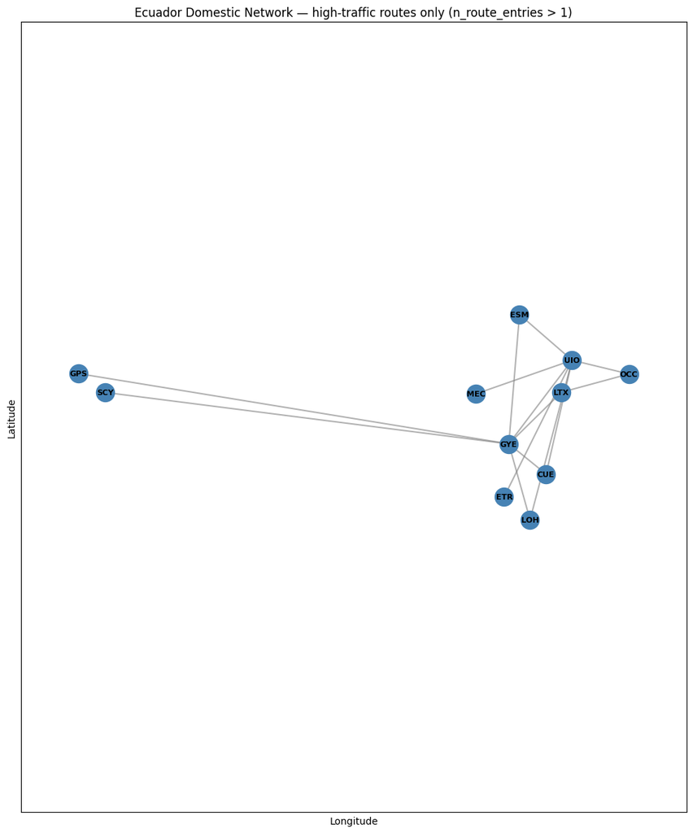

```python
# Geographic layout: use (longitude, latitude) as each node's position, same as in the Section 4 preview
import matplotlib.pyplot as plt
pos_filtered = {node: (data['lon'], data['lat']) for node, data in G_filtered.nodes(data=True)}

plt.figure(figsize=(10, 12))

nx.draw_networkx_edges(G_filtered, pos_filtered, alpha=0.6, width=1.5, edge_color='gray')
nx.draw_networkx_nodes(G_filtered, pos_filtered, node_size=350, node_color='steelblue')
nx.draw_networkx_labels(G_filtered, pos_filtered, font_size=8, font_weight='bold')

plt.title("Ecuador Domestic Network — high-traffic routes only (n_route_entries > 1)")
plt.xlabel("Longitude")
plt.ylabel("Latitude")
plt.axis('equal')
plt.tight_layout()
plt.savefig('filtered_high_traffic_network.png', dpi=150)
plt.show()
```

```python
# Compare the original set of pairs vs. the filtered set
original_pairs = set(pair_counts['pair'])
filtered_pairs = set(pair_counts_filtered['pair'])
disappeared_pairs = original_pairs - filtered_pairs

print(f"Routes that disappeared ({len(disappeared_pairs)} of {len(original_pairs)}):")
for pair in sorted(disappeared_pairs):
    n_orig = pair_counts.loc[pair_counts['pair'] == pair, 'n_route_entries'].values[0]
    print(f"  {pair[0]} - {pair[1]}  (had {n_orig} route entry/entries)")
```

```
Routes that disappeared (4 of 18):
  TNW - UIO  (had 1 route entry/entries)
  TNW - XMS  (had 1 route entry/entries)
  TUA - UIO  (had 1 route entry/entries)
  UIO - XMS  (had 1 route entry/entries)
```

Filtering the network to city pairs with more than one route entry retains 14 of the original 18 connections (77.8%) and 11 of the original 14 airports (78.6%). The three airports removed are `TNW` (Tena), `TUA` (Tulcán), and `XMS` (Macas). Their incident connections—TNW–UIO, TNW–XMS, TUA–UIO, and XMS–UIO—each had only one route entry. Once these four edges were filtered out, the three airports became isolated and were therefore removed from the graph. Notably, TNW and XMS originally had two connections each, but neither connection passed the threshold.

This pruning is geographically meaningful. The removed airports serve comparatively peripheral markets in the Amazon region and near Ecuador's northern border. Their disappearance suggests that repeated route representation is concentrated around larger population centers, major hubs, and tourism markets rather than being distributed evenly across the country.

The filtered network remains strongly organized around the country's two principal hubs, `GYE` (Guayaquil) and `UIO` (Quito). The most heavily represented city pair is GYE–UIO, with 13 route entries, well above every other connection. This is consistent with its role as Ecuador's principal economic and transportation corridor. The second-largest value is GYE–SCY, with 8 entries, connecting Guayaquil with San Cristóbal in the Galápagos. Although San Cristóbal is geographically remote and has a much smaller population, its importance as a tourism destination creates substantial demand. Together, these routes demonstrate that network intensity reflects economic and tourism demand more clearly than geographic proximity alone — though this is one comparison and shouldn't be generalized without more route-level context.

A second tier consists of CUE–UIO, GPS–GYE, and OCC–UIO, each with four entries. The other retained pairs have two entries. These connections extend the network from Quito and Guayaquil toward Cuenca, Baltra, Coca, Loja, Esmeraldas, Manta, Latacunga, Santa Rosa, and San Cristóbal. Consequently, the filtering does not change the network's fundamental hub-and-spoke structure; instead, it makes that structure more pronounced by removing weaker peripheral links.

The geographic map adds information that the table alone cannot show. Most mainland airports form a relatively compact spatial cluster around the two hubs, while `GPS` and `SCY`, the Galápagos airports, appear far to the west. In the filtered network, both islands connect to the mainland through Guayaquil—GPS–GYE and SCY–GYE—making `GYE` the principal gateway between the mainland and the Galápagos. This spatial separation supports the earlier community analysis: the Galápagos airports occupy a distinct geographic and structural position while depending on Guayaquil for access to the wider domestic network.

Overall, the filter does not shrink the network uniformly. It selectively removes low-frequency peripheral connections while preserving the routes associated with Ecuador's two dominant hubs and its major tourism destinations. The resulting network is smaller but more centralized, emphasizing the importance of Quito, Guayaquil, and the Guayaquil–Galápagos corridor.

One important limitation is that the map displays all retained edges with the same thickness. As a result, GYE–UIO, with 13 entries, looks identical to a connection with only two entries. The weights remain stored in `G_filtered`, but they are not visually encoded. Mapping edge width or color intensity to `n_route_entries` would communicate differences in route intensity more effectively.

Finally, `n_route_entries` should be treated as a measure of dataset representation, not automatically as passenger volume, flight frequency, or airline competition. Multiple entries could reflect different airlines, directions, services, or duplicate records, depending on the dataset's structure. Therefore, the graph provides strong evidence about repeated route records and network structure, but claims about market demand or competition should be interpreted as plausible explanations rather than direct measurements.

## 🎯 Activity 2: A Population-Normalized Choropleth

Sections 8 and 9 built a choropleth from a genuinely per-region quantity (conservation hectares) and a symbol map from raw incident counts. Now combine both ideas: build a **choropleth of the detention/apprehension rate per 100,000 inhabitants, by province**, using the `raw_counts` table you already built in Section 12.

Steps:

1. Using `raw_counts`, build a Plotly `choropleth` (like Section 9's, but at the **province** level, so use `provincias_geojson` and `featureidkey='properties.dpa_provin'` instead of the canton file).
2. Color by `tasa_100k` with a sequential color scale (pick any single hue — try `'Reds'` or `'Oranges'` to visually distinguish this map from Section 8's green conservation map).
3. In a markdown cell below your map, compare it to the **raw count** choropleth you'd get by coloring the same map with `Casos` instead of `tasa_100k`. Which provinces look most different between the two versions? Does that match what you saw in the bar charts in Section 12?

```python
fig_rate_choro = px.choropleth(
    raw_counts,
    geojson=provincias_geojson,
    locations='codigo_provincia',
    featureidkey='properties.dpa_provin',
    color='tasa_100k',
    color_continuous_scale='Reds',
    hover_name='nombre_provincia',
    hover_data={
        'codigo_provincia': False,
        'Casos': True,
        'poblacion': ':.0f',
        'tasa_100k': ':.1f',
    },
    labels={'tasa_100k': 'Cases per 100k'},
)
fig_rate_choro.update_geos(fitbounds='locations', visible=False)
fig_rate_choro.update_layout(
    title='Detentions/Apprehensions Rate by Province — Per 100,000 Inhabitants',
    margin=dict(l=0, r=0, t=60, b=0),
    height=650,
)

fig_raw_choro = px.choropleth(
    raw_counts,
    geojson=provincias_geojson,
    locations='codigo_provincia',
    featureidkey='properties.dpa_provin',
    color='Casos',
    color_continuous_scale='Reds',
    hover_name='nombre_provincia',
    hover_data={
        'codigo_provincia': False,
        'Casos': True,
        'poblacion': ':.0f',
        'tasa_100k': ':.1f',
    },
    labels={'Casos': 'Raw cases'},
)
fig_raw_choro.update_geos(fitbounds='locations', visible=False)
fig_raw_choro.update_layout(
    title='Detentions/Apprehensions by Province — Raw Counts',
    margin=dict(l=0, r=0, t=60, b=0),
    height=650,
)

from IPython.display import display, HTML

display(HTML(f"""
<div style="display:flex; gap:20px;">
    <div>{fig_rate_choro.to_html(full_html=False, include_plotlyjs='cdn')}</div>
    <div>{fig_raw_choro.to_html(full_html=False, include_plotlyjs=False)}</div>
</div>
"""))
```

[interactive chart not shown]

### Activity 2 – Interpretation

The map based on Cases (absolute values) primarily shows where the largest number of arrests or apprehensions is concentrated. In this type of representation, highly populated provinces such as Guayas and Pichincha stand out, since a larger population generally leads to a higher total number of incidents. However, this visualization can be misleading when comparing provinces with significantly different population sizes.

In contrast, the map based on `tasa_100k` represents the number of cases per 100,000 inhabitants, allowing for a fairer comparison across provinces. By normalizing the data by population, some provinces with relatively small populations but a comparatively high number of cases become much more prominent. Conversely, densely populated provinces may appear less intense because their cases are distributed across a much larger population.

The most noticeable differences are typically observed in Amazonian or island provinces such as Galápagos, Pastaza, Napo, and Sucumbíos, which may exhibit high incidence rates despite having a relatively low absolute number of cases. In contrast, provinces such as Guayas, Pichincha, and Manabí, which rank among the most prominent in the absolute case map, become less dominant when incidence is measured on a per-capita basis.

The absolute case map is useful for identifying where the greatest volume of incidents occurs, whereas the normalized map (`tasa_100k`) highlights where the phenomenon has the greatest relative impact on the population. Therefore, the rate per 100,000 inhabitants is the most appropriate measure when the objective is to compare the level of incidence across provinces with substantially different population sizes.

## 🎯 Activity 3: Community-Colored Adjacency Matrix for Ecuador's Network

Section 7 built **two** different adjacency matrices: a degree-ordered one for Ecuador's small domestic network (`G`), and a community-colored one for the much larger South America network (`G_sa`). The community-coloring trick was only ever applied to the big network — `G`'s matrix stayed ordered by degree alone, with no community information shown.

Using `G`, the `communities` you already detected with Louvain in Section 6, and the `community_of`/`community_colors` you already built there:

1. Build a node ordering that groups airports by **community first**, then by **degree within each community** — same idea as the South America version's `community_order`, but applied to `G` instead of `G_sa`.
2. Build the adjacency matrix with `nx.to_pandas_adjacency(G, nodelist=your_order)`, then recolor it so each filled cell inherits its **row airport's community color**, exactly as Section 7 did for South America, and render it with `px.imshow`.
3. In a markdown cell below your matrix, compare this community-colored version to Section 7's original degree-only matrix for the same network (`G`). Does the community coloring reveal anything the plain degree-ordered version didn't, given that the network only has three communities and 14 airports total?

```python
# Activity 3 — Community-colored adjacency matrix for Ecuador's network (G)

ec_degree = dict(G.degree())
ec_comm_order = sorted(G.nodes(), key=lambda n: (community_of[n], -ec_degree[n], n))

adj_ec_comm = nx.to_pandas_adjacency(G, nodelist=ec_comm_order)

# Recolor filled cells so each row inherits its community index.
row_comm = [community_of[n] for n in ec_comm_order]
n_comm_ec = len(set(row_comm))
adj_ec_colored = adj_ec_comm.copy()
for i, node in enumerate(ec_comm_order):
  adj_ec_colored.iloc[i] = adj_ec_colored.iloc[i] * (community_of[node] + 1)

# Build a discrete-ish colorscale: 0 is background, >0 are community colors.
ec_colors = [community_colors[str(i)] for i in sorted(set(row_comm))]
ec_colorscale = [[0.0, '#fcfcfb']]
for i, color in enumerate(ec_colors, start=1):
  t = i / n_comm_ec
  ec_colorscale.append([t, color])

fig_matrix_ec_comm = px.imshow(
  adj_ec_colored,
  color_continuous_scale=ec_colorscale,
  aspect='equal',
  zmin=0, zmax=n_comm_ec,
  labels=dict(x='Airport (community-ordered)', y='Airport (community-ordered)'),
)
fig_matrix_ec_comm.update_layout(
  title="Ecuador's Domestic Flight Network — Community-Colored Adjacency Matrix<br>"
        "<sub>Order: community first, then degree within each community</sub>",
  coloraxis_showscale=False,
  height=620, width=680,
  margin=dict(l=0, r=0, t=70, b=0),
)
fig_matrix_ec_comm.show()

# 3) Quick comparison numbers for the written answer.
print(f"Airports in G: {len(ec_comm_order)}")
print(f"Communities in G: {n_comm_ec}")
print("Community membership:")
for cid in sorted(set(row_comm)):
  members = sorted([n for n in ec_comm_order if community_of[n] == cid])
  print(f"  Community {cid}: {members}")
```

[interactive chart not shown]

```
Airports in G: 14
Communities in G: 3
Community membership:
  Community 0: ['LTX', 'OCC']
  Community 1: ['CUE', 'ESM', 'GPS', 'GYE', 'LOH', 'SCY']
  Community 2: ['ETR', 'MEC', 'TNW', 'TUA', 'UIO', 'XMS']
```

## Activity 3 markdown

In Section 7, the original adjacency matrix is ordered solely by airport degree, meaning airports are arranged according to the number of connections they have, with the most frequently visited airports appearing first. In this visualization, however, the matrix is first grouped by community and then ordered by airport degree within each community. Although the overall travel patterns remain consistent between the two visualizations, the community-based ordering provides additional structural insights that are not as apparent in the original matrix.

Both the original matrix from Section 7 and this community-ordered version clearly show that **UIO** and **GYE** are the primary destination airports in Ecuador's domestic network. These airports stand out because they receive the highest volume of connections, making them the dominant travel hubs in the network.

The community-ordered matrix, however, reveals an important characteristic that is difficult to observe in the degree-only visualization. It becomes evident that several communities are centered around a single dominant airport, such as **UIO**, **GYE**, or **OCC**. Within these communities, one airport serves as the primary hub, concentrating most of the incoming and outgoing connections. This highlights the hierarchical structure of the network and demonstrates how certain airports dominate travel within their respective communities—an insight that is largely hidden in the original degree-ordered matrix.

For this small network, both versions tell a very similar story (so the gain is modest), but the community-colored version is clearer if the task is specifically “where are the community boundaries?” rather than “who are the hubs?”.

## 🎯 Activity 4: A Point Density Heatmap

Section 11's dot density map plots all ~38,000 incidents as individual points, but at that volume many points overlap and the densest areas just look like solid blobs — you can't tell whether a "solid" patch has 50 incidents or 5,000. A **density heatmap** solves this differently: instead of drawing one mark per incident, it estimates a smooth *intensity surface* from the point locations themselves, so density differences remain visible even where individual points would fully overlap.

Using `mdi_land`'s `latitud`/`longitud` columns:

1. Build a density heatmap with `px.density_map` (`lat=`, `lon=`, `radius=`, plus `map_style='open-street-map'` so the country's outline is visible underneath). Center the map on continental Ecuador and pick a `zoom` level that shows the whole country.
2. Try at least two different `radius` values. What changes visually, and why does a radius that's too large make the map *less* informative rather than more?
3. In a markdown cell below your map, compare what this idiom shows you about Quito and Guayaquil versus what Section 11's dot density map and Section 9's choropleth each showed about the same two cities. Are all three telling the same story, or does the density heatmap reveal something the other two idioms don't?

```python
# Activity 4 — Density heatmap with two radius values

center_ec = {'lat': -1.5, 'lon': -78.5}
zoom_ec = 5.2

# Plotly versions differ: newer uses px.density_map, older uses px.density_mapbox.
use_density_map = hasattr(px, 'density_map')

def show_density(radius):
  if use_density_map:
    fig_hm = px.density_map(
      mdi_land,
      lat='latitud',
      lon='longitud',
      radius=radius,
      center=center_ec,
      zoom=zoom_ec,
      map_style='open-street-map',
      hover_name='nombre_canton',
      title=f'Detention/Apprehension Density Heatmap — radius={radius}',
    )
  else:
    fig_hm = px.density_mapbox(
      mdi_land,
      lat='latitud',
      lon='longitud',
      radius=radius,
      center=center_ec,
      zoom=zoom_ec,
      mapbox_style='open-street-map',
      hover_name='nombre_canton',
      title=f'Detention/Apprehension Density Heatmap — radius={radius}',
    )

    fig_hm.update_layout(
      margin=dict(l=0, r=0, t=60, b=0),
      height=650,
    )
  fig_hm.show()
```

```python
show_density(radius=22)
```

[interactive chart not shown]

```python
show_density(radius=2)
```

[interactive chart not shown]

```python
show_density(radius=5)
```

[interactive chart not shown]

```python
show_density(radius=8)
```

[interactive chart not shown]

## Activity 4 — Interpretation

With **radius=8**, the map preserves more local variation: Quito and Guayaquil each show compact high-intensity cores with nearby secondary hotspots still distinguishable. With **radius=22**, those local peaks blur into wider smooth regions, and nearby hotspots merge into single blobs.

A radius that is too large becomes less informative because it over-smooths the data: different neighborhoods (or even different cities if close enough) can look artificially similar, hiding the true spatial structure.

Compared with Section 11's dot map, the heatmap makes relative intensity easier to read where points overlap heavily. Compared with Section 9's choropleth, it is not constrained by administrative boundaries, so it can reveal intra-city gradients. All three are related, but not identical: the choropleth summarizes by region, the dot map shows raw observations, and the density heatmap best highlights continuous concentration patterns around Quito and Guayaquil.

I think that for this particular task, using a radius below 8 is appropiate, as it shows a little more detail into the points around the country